# DEM 7283 - Example 2 - Logit and Probit Models

Corey Sparks, PhD

07 February, 2022

## Regression example

Next we apply this logic to a regression case. First we fit the OLS model for our BMI outcome using education and age as predictors:

```r
fit1<-lm(bmi~educ+agec,
         data=brfss20)
```

Next we incorporate case weights

```r
fit2<-lm(bmi~educ+agec,
         data=brfss20,
         weights = mmsawt)
```

Now we will incorporate design effects as well:

```r
fit3<-svyglm(bmi~educ+agec,
             design = des,
             family=gaussian)
```

Now I make a table to show the results of the three models:

```r
stargazer(fit1, fit2, fit3,
          style="demography", type="html",
          column.labels = c("OLS", "Weights Only", "Survey Design"),
          title = "Regression models for BMI using survey data - BRFSS 2016",
          covariate.labels=c( "SomeHS","hsGRAD", "SomeColl", "CollGrad", "Age 24-39","Age 39-59" ,"Age 59-79", "Age 80+"),
          keep.stat="n",
          model.names=F,
          align=T,
          ci=T)
```

**Regression models for BMI using survey data - BRFSS 2016**

|  | bmi |  |  |
| --- | --- | --- | --- |
|  | OLS | Weights Only | Survey Design |
|  | Model 1 | Model 2 | Model 3 |
| SomeHS | -0.320* | 0.122 | 0.122 |
|  | (-0.589, -0.050) | (-0.065, 0.309) | (-0.624, 0.868) |
| hsGRAD | -0.520*** | -0.617*** | -0.617 |
|  | (-0.751, -0.288) | (-0.780, -0.455) | (-1.277, 0.043) |
| SomeColl | -0.636*** | -0.742*** | -0.742* |
|  | (-0.867, -0.405) | (-0.903, -0.581) | (-1.399, -0.085) |
| CollGrad | -1.928*** | -2.127*** | -2.127*** |
|  | (-2.156, -1.700) | (-2.287, -1.967) | (-2.774, -1.480) |
| Age 24-39 | 2.263*** | 2.333*** | 2.333*** |
|  | (2.150, 2.377) | (2.237, 2.430) | (2.093, 2.573) |
| Age 39-59 | 2.849*** | 2.852*** | 2.852*** |
|  | (2.753, 2.945) | (2.769, 2.936) | (2.640, 3.065) |
| Age 59-79 | 2.165*** | 2.243*** | 2.243*** |
|  | (2.071, 2.260) | (2.155, 2.332) | (2.034, 2.453) |
| Age 80+ | -0.153* | -0.030 | -0.030 |
|  | (-0.286, -0.019) | (-0.181, 0.121) | (-0.406, 0.346) |
| Constant | 27.331*** | 27.207*** | 27.207*** |
|  | (27.092, 27.569) | (27.041, 27.372) | (26.544, 27.870) |
| *N* | 173,044 | 173,044 | 173,044 |
| p < .05; p < .01; p < .001 |  |  |  |

Notice, the results for the education levels are much *less* significant than the were with either of the other two analysis. This is because those models had standard errors for the parameters that were too small. You see all the standard errors are larger and the T statistics are smaller.

Which shows the same $\beta$’s between the survey design model and the weighted model but the standard errors are larger in the survey model, so the test statistics are more conservative (smaller t statistics).

It may be informative to plot the results of the models to see how different the coefficients are from one another:

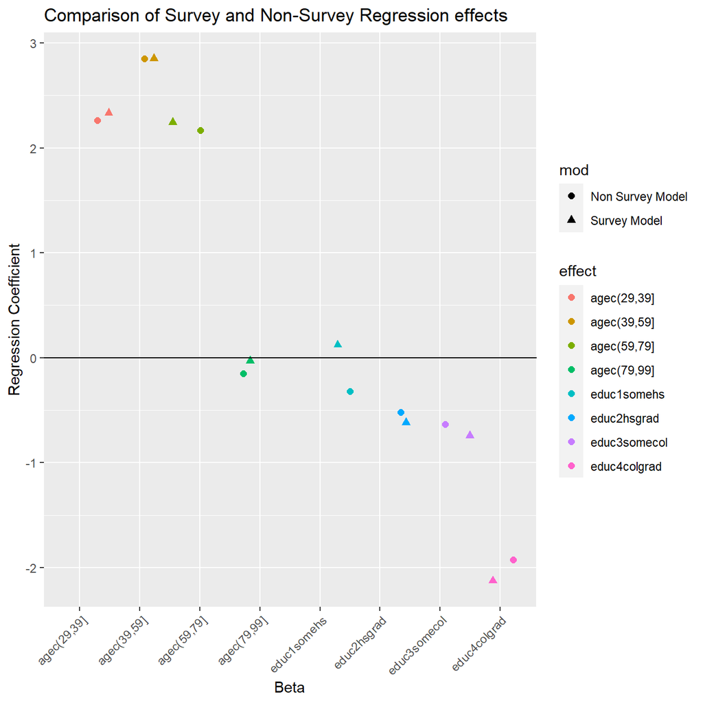

```r
library(ggplot2)
library(dplyr)
coefs<-data.frame(coefs=c(coef(fit1)[-1], coef(fit3)[-1]),
                  mod=c(rep("Non Survey Model", 8),rep("Survey Model", 8)),
                  effect=rep(names(coef(fit1)[-1]), 2))

coefs%>%
  ggplot()+
  geom_point(aes( x=effect,
                  y=coefs,
                  group=effect,
                  color=effect,
                  shape=mod),
             position=position_jitterdodge(jitter.width = 1),
             size=2)+
  ylab("Regression Coefficient")+
  xlab("Beta")+
  geom_abline(intercept = 0, slope=0)+
  theme(axis.text.x = element_text(angle = 45, hjust = 1))+
  ggtitle(label = "Comparison of Survey and Non-Survey Regression effects")
```

Which shows us that the betas are similar but have some differences between the two models.

## Creating Survey estimates for places

```r
citytab<-svyby(~obese,
               ~mmsaname,
               design=des,
               FUN = svymean,
               na.rm=T )

knitr::kable(citytab[ 1:10, ],
             digits=3,
             caption = "Obesity Estimats for TX MSAs")
```

|  | mmsaname | obese | se |
| --- | --- | --- | --- |
| Aberdeen, SD, Micropolitan Statistical Area | Aberdeen, SD, Micropolitan Statistical Area | 0.293 | 0.027 |
| Akron, OH, Metropolitan Statistical Area | Akron, OH, Metropolitan Statistical Area | 0.312 | 0.023 |
| Albany-Schenectady-Troy, NY, Metropolitan Statistical Area | Albany-Schenectady-Troy, NY, Metropolitan Statistical Area | 0.249 | 0.019 |
| Albuquerque, NM, Metropolitan Statistical Area | Albuquerque, NM, Metropolitan Statistical Area | 0.295 | 0.018 |
| Anchorage, AK, Metropolitan Statistical Area | Anchorage, AK, Metropolitan Statistical Area | 0.326 | 0.021 |
| Atlanta-Sandy Springs-Alpharetta, GA, Metropolitan Statistical Area | Atlanta-Sandy Springs-Alpharetta, GA, Metropolitan Statistical Area | 0.313 | 0.014 |
| Augusta-Richmond County, GA-SC, Metropolitan Statistical Area | Augusta-Richmond County, GA-SC, Metropolitan Statistical Area | 0.396 | 0.032 |
| Austin-Round Rock-Georgetown, TX, Metropolitan Statistical Area | Austin-Round Rock-Georgetown, TX, Metropolitan Statistical Area | 0.275 | 0.015 |
| Baltimore-Columbia-Towson, MD, Metropolitan Statistical Area | Baltimore-Columbia-Towson, MD, Metropolitan Statistical Area | 0.322 | 0.009 |
| Baton Rouge, LA, Metropolitan Statistical Area | Baton Rouge, LA, Metropolitan Statistical Area | 0.352 | 0.021 |

### Using srvyr

There’s a new package called `srvyr` that incorporates the survey analysis stuff into the `dplyr` universe:

```r
library(srvyr)
brfsurv<-brfss20%>%
  as_survey_design(strata=ststr,
                   weights=mmsawt )


brfsurv%>%
  group_by(mmsaname)%>%
    summarise(obprev = survey_mean(obese, na.rm=T))
```

## Replicate Weights

If your dataset comes with *replicate weights*, you have to specify the survey design slightly differently. Here is an example using the IPUMS CPS data. For this data, you can get information [here](https://cps.ipums.org/cps/repwt.shtml), but you must consult your specific data source for the appropriate information for your data.

```r
load(url("https://github.com/coreysparks/data/blob/master/cpsmar10tx.Rdata?raw=true"))
names(cpsmar10tx)
```

```
##   [1] "year"     "serial"   "hwtsupp"  "repwt"    "statefip" "metarea"
##   [7] "foodstmp" "REPWT1"   "REPWT2"   "REPWT3"   "REPWT4"   "REPWT5"
##  [13] "REPWT6"   "REPWT7"   "REPWT8"   "REPWT9"   "REPWT10"  "REPWT11"
##  [19] "REPWT12"  "REPWT13"  "REPWT14"  "REPWT15"  "REPWT16"  "REPWT17"
##  [25] "REPWT18"  "REPWT19"  "REPWT20"  "REPWT21"  "REPWT22"  "REPWT23"
##  [31] "REPWT24"  "REPWT25"  "REPWT26"  "REPWT27"  "REPWT28"  "REPWT29"
##  [37] "REPWT30"  "REPWT31"  "REPWT32"  "REPWT33"  "REPWT34"  "REPWT35"
##  [43] "REPWT36"  "REPWT37"  "REPWT38"  "REPWT39"  "REPWT40"  "REPWT41"
##  [49] "REPWT42"  "REPWT43"  "REPWT44"  "REPWT45"  "REPWT46"  "REPWT47"
##  [55] "REPWT48"  "REPWT49"  "REPWT50"  "REPWT51"  "REPWT52"  "REPWT53"
##  [61] "REPWT54"  "REPWT55"  "REPWT56"  "REPWT57"  "REPWT58"  "REPWT59"
##  [67] "REPWT60"  "REPWT61"  "REPWT62"  "REPWT63"  "REPWT64"  "REPWT65"
##  [73] "REPWT66"  "REPWT67"  "REPWT68"  "REPWT69"  "REPWT70"  "REPWT71"
##  [79] "REPWT72"  "REPWT73"  "REPWT74"  "REPWT75"  "REPWT76"  "REPWT77"
##  [85] "REPWT78"  "REPWT79"  "REPWT80"  "REPWT81"  "REPWT82"  "REPWT83"
##  [91] "REPWT84"  "REPWT85"  "REPWT86"  "REPWT87"  "REPWT88"  "REPWT89"
##  [97] "REPWT90"  "REPWT91"  "REPWT92"  "REPWT93"  "REPWT94"  "REPWT95"
## [103] "REPWT96"  "REPWT97"  "REPWT98"  "REPWT99"  "REPWT100" "REPWT101"
## [109] "REPWT102" "REPWT103" "REPWT104" "REPWT105" "REPWT106" "REPWT107"
## [115] "REPWT108" "REPWT109" "REPWT110" "REPWT111" "REPWT112" "REPWT113"
## [121] "REPWT114" "REPWT115" "REPWT116" "REPWT117" "REPWT118" "REPWT119"
## [127] "REPWT120" "REPWT121" "REPWT122" "REPWT123" "REPWT124" "REPWT125"
## [133] "REPWT126" "REPWT127" "REPWT128" "REPWT129" "REPWT130" "REPWT131"
## [139] "REPWT132" "REPWT133" "REPWT134" "REPWT135" "REPWT136" "REPWT137"
## [145] "REPWT138" "REPWT139" "REPWT140" "REPWT141" "REPWT142" "REPWT143"
## [151] "REPWT144" "REPWT145" "REPWT146" "REPWT147" "REPWT148" "REPWT149"
## [157] "REPWT150" "REPWT151" "REPWT152" "REPWT153" "REPWT154" "REPWT155"
## [163] "REPWT156" "REPWT157" "REPWT158" "REPWT159" "REPWT160" "month"
## [169] "pernum"   "wtsupp"   "relate"   "age"      "sex"      "race"
## [175] "marst"    "offpov"   "MIGRATE1"
```

So we see the replicate weights are in columns 8 through 167 in the data

```r
#simple binary outcome
cpsmar10tx$poverty<-ifelse(cpsmar10tx$offpov==1,1,0)

# Replicate weight design - I got these details from the data source, you should too
des2<-svrepdesign( data = cpsmar10tx,
                   repweights = cpsmar10tx[, c(8:167)]  ,
                   weights = ~wtsupp ,
                   type="JK1",
                   scale=.025)
des2
```

```
## Call: svrepdesign.default(data = cpsmar10tx, repweights = cpsmar10tx[,
##     c(8:167)], weights = ~wtsupp, type = "JK1", scale = 0.025)
## Unstratified cluster jacknife (JK1) with 160 replicates.
```

```r
#Without design
prop.table(table(cpsmar10tx$poverty))
```

```
##
##         0         1
## 0.8374617 0.1625383
```

```r
#with design
prop.table(svytable(~poverty,
                    design = des2))
```

```
## poverty
##         0         1
## 0.8481106 0.1518894
```

```r
#Again, using the mean
mean(cpsmar10tx$poverty)
```

```
## [1] 0.1625383
```

```r
#Using the design. This would be an official estimate of poverty in TX in 2010:
svymean(~poverty,
        design=des2)
```

```
##            mean    SE
## poverty 0.15189 0.007
```

# Categorical outcomes

In the vast majority of situations in your work as demographers, your outcome will either be of a qualitative nature or non-normally distributed, especially if you work with individual level survey data.

When we speak of qualitative outcomes, we generally are concerned with the observation of:

- A particular behavior (marriage, migration, birth, death)
- A transition (unemployed to employed, married to divorced)
- A threshold characteristic (adoption of sterilization after ideal # of children is reached)
- In general, each of these outcomes would be coded as a binary variable (1 or 0) depending on whether the outcome of interest was observed

## Basics of Genearlized Linear Models

Up until now, we have been relying on linear statistical models which assumed the Normal distribution for our outcomes. A broader class of regression models, are [*Generalized Linear Models*](https://en.wikipedia.org/wiki/Generalized_linear_model), or GLMs, which allow for linear regression for outcomes that are not assumed to come from a Normal distribution.

GLMs are a class of statistical models that link the mean of the specified distribution to a linear combination of covariates by some form of *link function*. For example, the Normal distribution has the mean, $\mu$, which is typically estimated using the *linear mean function* :

$$\mu = \beta_0 + \beta_1 x_1$$
Which describes the line that estimates the mean of the outcome variable as a linear function of the predictor variable $x_1$. This model uses an *identity link* meaning there is no transformation of the linear mean function as it is connected to the mean of the outcome.

This can be written as:

$$g(u) = g(E(Y)) = \beta_0 + \beta_1
x_1$$

Where $g()$ is the link function, linking the mean of the Normal distribution to the linear mean function of the model.

The linear model is appropriate for the Normal distribution, because this distribution can take any value from $- \infty$ to $\infty$. Other distributions do not have this wide range, so transformations of the linear mean function must be used so that the linear model remains on the scale of the data.

You have probably seen the binomial distribution in either a basic statistics course, remember the coin flips? Or in the context of a logistic regression model.

There are two ways the binomial distribution is typically used, the first is the context of logistic regression, where a special case of the binomial is used, called the *Bernoulli* distribution. This is the case of the binomial when there is basically a single coin flip, and you’re trying to figure out the probability that it is heads (or tails). This is said to be a single *trial*, and the outcome is either 1 or 0 (heads or tails).

The second way the binomial is used is when you have multiple trials, and you’re trying to estimate the probability of the event occurring over multiple trials. In this case, your number of trials, $n$ can be large, and your number of successes, $y$ is the random variable under consideration. This is the basic makeup of a demographic rate, the count-based binomial.

The mean of the binomial distribution is a proportion or a probability, $\pi$, which tells you how likely it is that the event your interested in occurs. Any model using the binomial distributor will be geared towards estimating the probability.

When a variable is coded as binary, meaning either 1 or 0, the Bernoulli distribution is used, as in the logistic regression model. When coded like this, the model tries to use the other measured information to predict the 1 value versus the 0 value. So in the basic sense, we want to construct a model like:

$$Pr(y=1) =\pi = \text{some function of
predictors}$$

The good thing is that, when we have count data, not just 1’s and 0’s, the same thing happens. The ratio or successes ($y$) to trials ($n$) is used to estimate $\pi$ and we build a model for that rate:

$$\text{Binomial} \binom{n}{y} =
\frac{y}{n} = \pi = \text{some function of predictors}$$

## Binary outcome variables

The ratio $\frac{y}{n}$ is a rate or probability, and as such has very strict bounds. Probabilities cannot be less than 0 or greater than 1, so again, we should not use the Normal distribution here, since it is valid for all real numbers. Instead, we are using the binomial, but we still run into the problem of having a strictly bounded value, $\pi$ that we are trying to estimate with a linear function.

Enter the link function again.

The binomial distribution typically uses either a [logit](https://en.wikipedia.org/wiki/Logit) or [probit](https://en.wikipedia.org/wiki/Probit) link function, but others such as the [complementary log-log link function](http://data.princeton.edu/wws509/notes/c3s7.html) are also used in certain circumstances. For now we will use the *logit* function.

The logit transforms the probability, $\pi$, which is bound on the interval $[0,1]$ into a new limitless interval similar to the normal distribution of $[-\infty, \infty]$. The transformation is knows a the log-odds transformation, or logit for short.

The odds of an event happening are the probability that something happens, divided by the probability it does not happen, in this case:

$$\text{odds }{\pi} =
\frac{\pi}{(1-\pi)}$$

Which is bound on the interval $[0, \infty]$, when we take the natural log of the odds, the value is transformed into the linear space, of $[-\infty, \infty]$.

$$\text{log-odds }{\pi} = log \left (
\frac{\pi}{(1-\pi)} \right)$$

This can be modeled using a linear function of covariates now, without worrying about the original boundary problem:

$$log \left (
\frac{\pi}{(1-\pi)} \right) = \beta_0 +\beta_1 x_1$$

or more compactly:

$$logit (\pi) = \beta_0 +\beta_1
x_1$$

## Interpretation of the binomial model

Similar to when the Poisson model was introduced, the binomial model also has a strange interpretation when compared to the OLS model.

Since we used the log-odds, or logit transformation of the mean of the outcome, $\pi$, the interpretations of the model $\beta$’s are not on a linear scale, they are on a log-odds scale.

While we can certainly interpret a positive $\beta$ as increasing the odds of $y$ occurring, or increasing the rate, and a negative $\beta$, as decreasing the odds, this is not commonly how the model effects are interpreted.

Instead, the common interpretation when using the logit model is the *odds ratio* interpretation of $\beta$. To obtain the odds ratio, you must exponentiate the $\beta$ from the model.

For example, a $\beta$ of 0.025 would be $\text{exp}(\beta) = 1.025$, and we would say that for a 1 unit increase in $x_1$, the odds of $y$ occurring are 2.5% higher.

This percentage is obtained by subtracting 1 from the $\text{exp}(\beta)$, or $\text{% change in odds} = \text{exp}(\beta) - 1$, which in this case is 0.025.

For a $\beta_1$ that is negative, such as $\beta_1 = -.15$, the exponent is 0.86. Following the rule we just used, we see that a one unit change in $x_1$ leads to a $\text{exp}(-0.15) - 1 = -.14$, or a 14% decrease in the odds of y occurring.

## Logit and Probit models

If our outcome is dichotomous (1/0), the natural distribution to consider for a GLM is the binomial

$$y \sim \
\text{Binomial}\binom{n}{p}$$
with $p$ being the mean of the binomial, and *n* being the number of trials, generally when you have individual data, *n* is always 1, and $p$ is the probability of observing the 1, conditional on the observed predictors.

There are two common techniques to estimate the mean, **logistic regression** and **probit regression**.

In a Logistic model, the link function is the inverse logit function, or

$\text{Logit}^{-1}(p) =log \frac{p}{(1-p)}$

Which gives us the following conditional mean model:

$$E(y|x) = \frac{1}{1+ exp({-\sum_k
\beta_k x_{ik}})}$$
Which situates the model within the logistic distribution function.

Expressing *p* as a linear model is done via this log odds transformation of the probability:

$$log \frac{p}{(1-p)} = \sum_k \beta_k
x_{ik}$$

For the Probit model, the link function is the inverse cumulative Normal distribution:

$$E(y|x) = \Phi^{-1}(p) = \Phi (\sum_k
\beta_k x_{ik})$$

In practice, these two models give very similar estimates and will have very similar interpretations, although the logistic regression model has the more convenient *odds ratio* interpretation of its $\beta's$, while the probit model’s coefficients are often transformed into marginal coefficients, which is more of a challenge and software generally doesn’t give you these by default.

## Logit/Probit Regression example

There is no trick to fitting logistic regression models using survey data, just use the `svyglm()` function with the appropriate distribution specified via `family=binomial` for logistic and `family=binomial(link="probit")` for the probit model. You don’t have to specify the link function if you’re just doing the logistic model, as it is the default.

### Example using BRFSS

This example will cover the use of R functions for fitting binary logit and probit models to complex survey data.

For this example I am using 2020 CDC Behavioral Risk Factor Surveillance System (BRFSS) SMART metro area survey data. [Link](https://www.cdc.gov/brfss/smart/smart_2020.html)

```r
#load libraries
library(car)
library(stargazer)
library(survey)
library(questionr)
library(dplyr)
library(tidyverse)
```

```r
#load brfss
brfss20<- readRDS(url("https://github.com/coreysparks/DEM7283/blob/master/data/brfss20sm.rds?raw=true"))
### Fix variable names
names(brfss20) <- tolower(gsub(pattern = "_",replacement =  "",x =  names(brfss20)))
```

```r
#Poor or fair self rated health
brfss20$badhealth<-Recode(brfss20$genhlth,
                           recodes="4:5=1; 1:3=0; else=NA")

#sex
brfss20$male<-as.factor(ifelse(brfss20$sex==1,
                                "Male",
                                "Female"))

#Age cut into intervals
brfss20$agec<-cut(brfss20$age80,
                   breaks=c(0,24,39,59,79,99))

#race/ethnicity
brfss20$black<-Recode(brfss20$racegr3,
                       recodes="2=1; 9=NA; else=0")
brfss20$white<-Recode(brfss20$racegr3,
                       recodes="1=1; 9=NA; else=0")
brfss20$other<-Recode(brfss20$racegr3,
                       recodes="3:4=1; 9=NA; else=0")
brfss20$hispanic<-Recode(brfss20$racegr3,
                          recodes="5=1; 9=NA; else=0")

brfss20$race_eth<-Recode(brfss20$racegr3,
                          recodes="1='nhwhite'; 2='nh_black'; 3='nh_other';4='nh_multirace'; 5='hispanic'; else=NA",
                          as.factor = T)

#insurance
brfss20$ins<-Recode(brfss20$hlthpln1,
                     recodes ="7:9=NA; 1=1;2=0")

#income grouping
brfss20$inc<-ifelse(brfss20$incomg==9,
                     NA,
                     brfss20$incomg)

#education level
brfss20$educ<-Recode(brfss20$educa,
                      recodes="1:2='0Prim'; 3='1somehs'; 4='2hsgrad'; 5='3somecol'; 6='4colgrad';9=NA",
                      as.factor=T)

#brfss20$educ<-relevel(brfss20$educ, ref='2hsgrad')

#employment
brfss20$employ<-Recode(brfss20$employ1,
                        recodes="1:2='Employed'; 2:6='nilf'; 7='retired'; 8='unable'; else=NA",
                        as.factor=T)

brfss20$employ<-relevel(brfss20$employ,
                         ref='Employed')

#marital status
brfss20$marst<-Recode(brfss20$marital,
                       recodes="1='married'; 2='divorced'; 3='widowed'; 4='separated'; 5='nm';6='cohab'; else=NA",
                       as.factor=T)

brfss20$marst<-relevel(brfss20$marst,
                        ref='married')

#Age cut into intervals
brfss20$agec<-cut(brfss20$age80,
                   breaks=c(0,29,39,59,79,99))

brfss20$ageg<-factor(brfss20$ageg)

#BMI, in the brfss20a the bmi variable has 2 implied decimal places, so we must divide by 100 to get real bmi's

brfss20$bmi<-brfss20$bmi5/100

brfss20$obese<-ifelse(brfss20$bmi>=30,
                       1,
                       0)
#smoking currently
brfss20$smoke<-Recode(brfss20$smoker3,
                       recodes="1:2 ='Current'; 3 ='Former';4 ='NeverSmoked'; else = NA",
                       as.factor=T)

brfss20$smoke<-relevel(brfss20$smoke,
                        ref = "NeverSmoked")
```

### Analysis

First, we will do some descriptive analysis, such as means and cross tabulations.

```r
sub<-brfss20 %>%
  select(badhealth,mmsaname, bmi, ageg,race_eth, marst, educ,white, black, hispanic, other, smoke, ins, mmsawt, ststr) %>%
  filter( complete.cases( . ))


#cat<-sample(1:nrow(sub), size = 1000, replace = FALSE)

#sub<-sub[cat, ]

#First we tell R our survey design
options(survey.lonely.psu = "adjust")
des<-svydesign(ids= ~1,
               strata= ~ststr,
               weights= ~mmsawt,
               data = sub )
```

First, we examine the % of US adults with poor/fair health by education level, and do a survey-corrected chi-square test for independence.

```r
cat<-svyby(formula = ~badhealth,
           by = ~educ,
           design = des,
           FUN = svymean,
           na.rm=T)

svychisq(~badhealth+educ,
         design = des)
```

```
##
##  Pearson's X^2: Rao & Scott adjustment
##
## data:  svychisq(~badhealth + educ, design = des)
## F = 317.77, ndf = 3.3073e+00, ddf = 5.3953e+05, p-value < 2.2e-16
```

### plot of estimates with standard errors

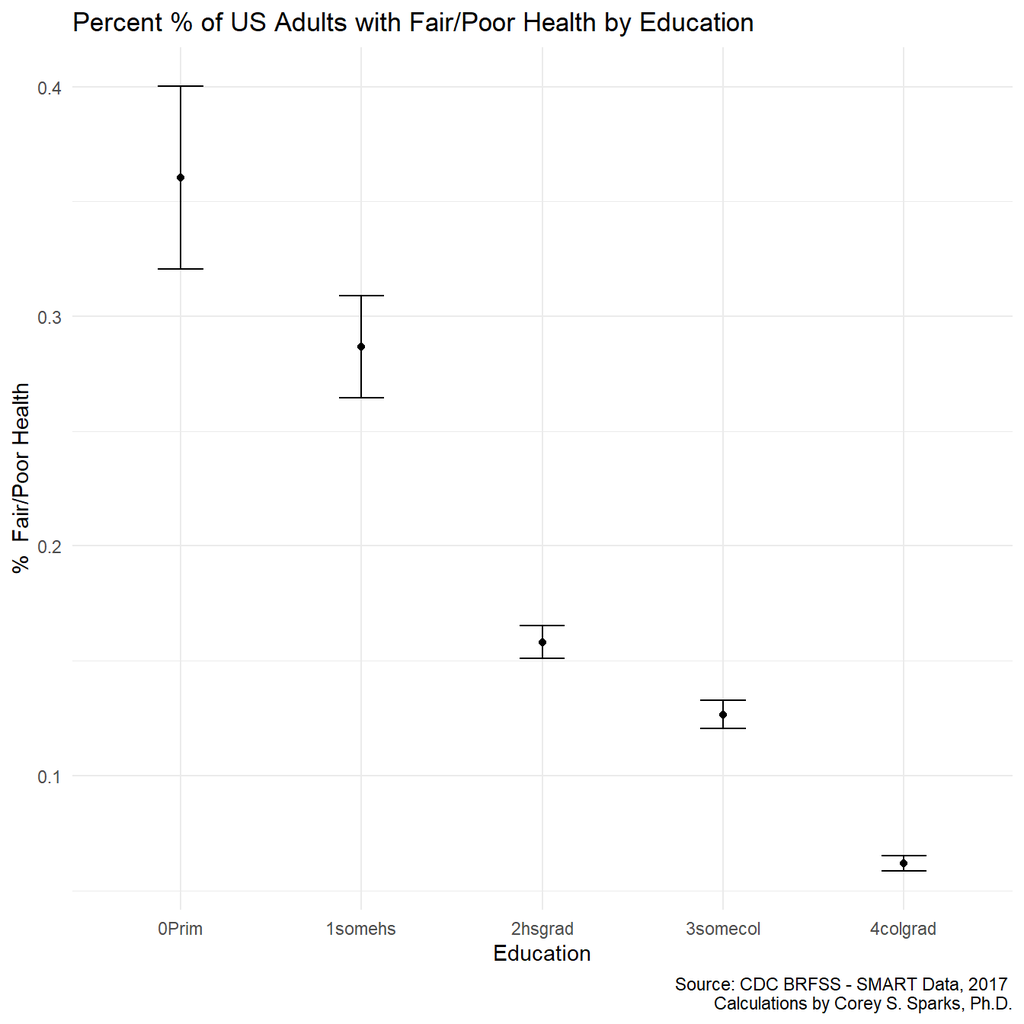

```r
cat%>%
  ggplot()+
  geom_point(aes(x=educ,y=badhealth))+
  geom_errorbar(aes(x=educ, ymin = badhealth-1.96*se,
                    ymax= badhealth+1.96*se),
                width=.25)+
   labs(title = "Percent % of US Adults with Fair/Poor Health by Education",
        caption = "Source: CDC BRFSS - SMART Data, 2017 \n Calculations by Corey S. Sparks, Ph.D.",
       x = "Education",
       y = "%  Fair/Poor Health")+
  theme_minimal()
```

### Calculate race*health cross tabulation, and plot it

```r
dog<-svyby(formula = ~badhealth,
           by = ~race_eth,
           design = des,
           FUN = svymean,
           na.rm=T)

svychisq(~badhealth+race_eth,
         design = des)
```

```
##
##  Pearson's X^2: Rao & Scott adjustment
##
## data:  svychisq(~badhealth + race_eth, design = des)
## F = 71.764, ndf = 3.441, ddf = 561331.299, p-value < 2.2e-16
```

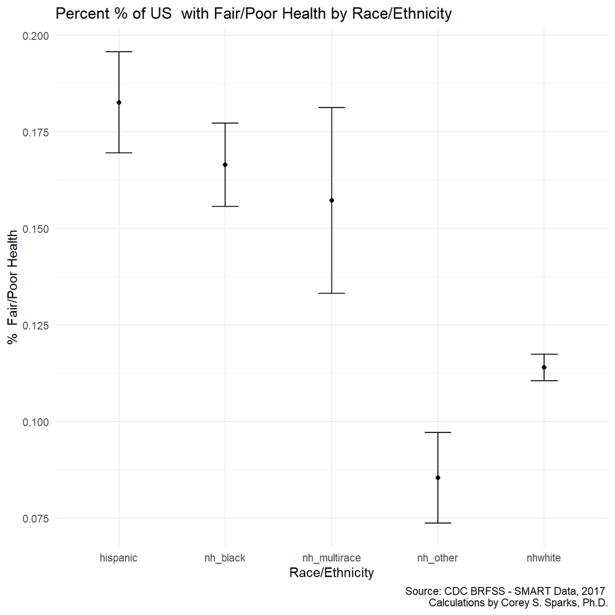

```r
dog%>%
  ggplot()+
  geom_point(aes(x=race_eth,y=badhealth))+
  geom_errorbar(aes(x=race_eth, ymin = badhealth-1.96*se,
                    ymax= badhealth+1.96*se),
                width=.25)+
   labs(title = "Percent % of US  with Fair/Poor Health by Race/Ethnicity",
        caption = "Source: CDC BRFSS - SMART Data, 2017 \n Calculations by Corey S. Sparks, Ph.D.",
       x = "Race/Ethnicity",
       y = "%  Fair/Poor Health")+
  theme_minimal()
```

### Calculate race by education by health cross tabulation, and plot it

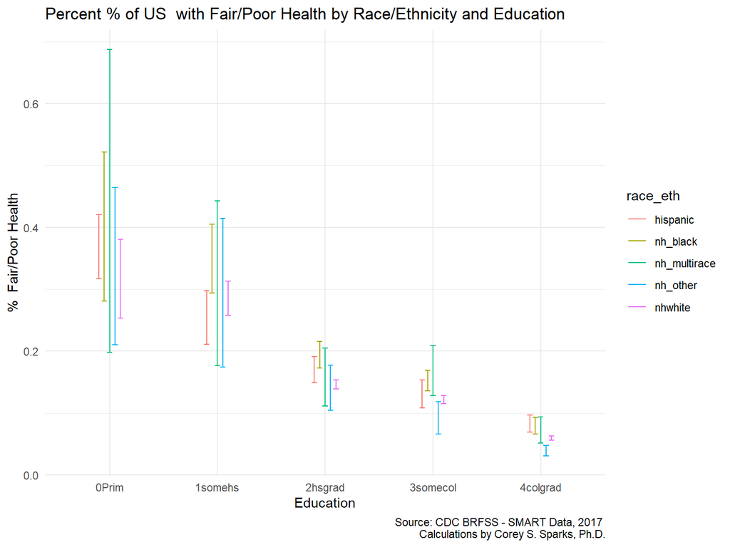

```r
catdog<-svyby(formula = ~badhealth,
              by = ~race_eth+educ,
              design = des,
              FUN = svymean,
              na.rm=T)

#this plot is a little more complicated, but facet_wrap() plots separate plots for groups

catdog%>%
  ggplot()+
  #geom_point(aes(x=educ, y = badhealth, color=race_eth, group=race_eth), position="dodge")+
  geom_errorbar(aes(x=educ,y = badhealth,
                    ymin = badhealth-1.96*se,
                   ymax= badhealth+1.96*se,
                   color=race_eth,
                   group=race_eth),
                width=.25,
                position="dodge")+
  #facet_wrap(~ race_eth, nrow = 3)+
  labs(title = "Percent % of US  with Fair/Poor Health by Race/Ethnicity and Education",
        caption = "Source: CDC BRFSS - SMART Data, 2017 \n Calculations by Corey S. Sparks, Ph.D.",
       x = "Education",
       y = "%  Fair/Poor Health")+
  theme_minimal()
```

## Fitting the logistic regression model

To fit the model to our survey data, we use `svyglm()`, and specify our model equation and name of our survey design object. Since we are using a logistic regression model, specify

```
family =
binomial
```

. The default link function is the logit:

```r
#Logit model
fit.logit<-svyglm(badhealth ~ race_eth + educ + ageg,
                  design = des,
                  family = binomial)
summary(fit.logit)
```

```
##
## Call:
## svyglm(formula = badhealth ~ race_eth + educ + ageg, design = des,
##     family = binomial)
##
## Survey design:
## svydesign(ids = ~1, strata = ~ststr, weights = ~mmsawt, data = sub)
##
## Coefficients:
##                      Estimate Std. Error t value Pr(>|t|)
## (Intercept)          -1.60935    0.11150 -14.434  < 2e-16 ***
## race_ethnh_black      0.03770    0.06477   0.582 0.560559
## race_ethnh_multirace  0.14544    0.10668   1.363 0.172809
## race_ethnh_other     -0.35524    0.09199  -3.862 0.000113 ***
## race_ethnhwhite      -0.37994    0.05293  -7.178 7.12e-13 ***
## educ1somehs          -0.13135    0.10545  -1.246 0.212907
## educ2hsgrad          -0.78013    0.09389  -8.309  < 2e-16 ***
## educ3somecol         -1.03801    0.09505 -10.921  < 2e-16 ***
## educ4colgrad         -1.82880    0.09446 -19.360  < 2e-16 ***
## ageg2                 0.45036    0.08832   5.099 3.42e-07 ***
## ageg3                 0.58022    0.08243   7.039 1.94e-12 ***
## ageg4                 1.03178    0.08163  12.640  < 2e-16 ***
## ageg5                 1.30242    0.07769  16.765  < 2e-16 ***
## ageg6                 1.54650    0.07492  20.643  < 2e-16 ***
## ---
## Signif. codes:  0 '***' 0.001 '**' 0.01 '*' 0.05 '.' 0.1 ' ' 1
##
## (Dispersion parameter for binomial family taken to be 1.000545)
##
## Number of Fisher Scoring iterations: 5
```

### Get odds ratios and confidence intervals for the estimates

the `tbl_regression` function in `gtsummary` is a good way to make a decent looking table easily and to exponentiate the regression effects to form odds ratios and their confidence intervals.

```r
library(gtsummary)
fit.logit%>%
  tbl_regression(exponentiate=TRUE )
```

| **Characteristic** | **OR**<sup>1</sup> | **95% CI**<sup>1</sup> | **p-value** |
| --- | --- | --- | --- |
| race_eth |  |  |  |
| hispanic | — | — |  |
| nh_black | 1.04 | 0.91, 1.18 | 0.6 |
| nh_multirace | 1.16 | 0.94, 1.43 | 0.2 |
| nh_other | 0.70 | 0.59, 0.84 | <0.001 |
| nhwhite | 0.68 | 0.62, 0.76 | <0.001 |
| educ |  |  |  |
| 0Prim | — | — |  |
| 1somehs | 0.88 | 0.71, 1.08 | 0.2 |
| 2hsgrad | 0.46 | 0.38, 0.55 | <0.001 |
| 3somecol | 0.35 | 0.29, 0.43 | <0.001 |
| 4colgrad | 0.16 | 0.13, 0.19 | <0.001 |
| ageg |  |  |  |
| 1 | — | — |  |
| 2 | 1.57 | 1.32, 1.87 | <0.001 |
| 3 | 1.79 | 1.52, 2.10 | <0.001 |
| 4 | 2.81 | 2.39, 3.29 | <0.001 |
| 5 | 3.68 | 3.16, 4.28 | <0.001 |
| 6 | 4.70 | 4.05, 5.44 | <0.001 |

<sup>*1*</sup> OR = Odds Ratio, CI = Confidence Interval

A sligtly more digestible form can be obtained from the `sjPlot` library. In this plot, if the error bars overlap 1, the effects are not statistically significant.

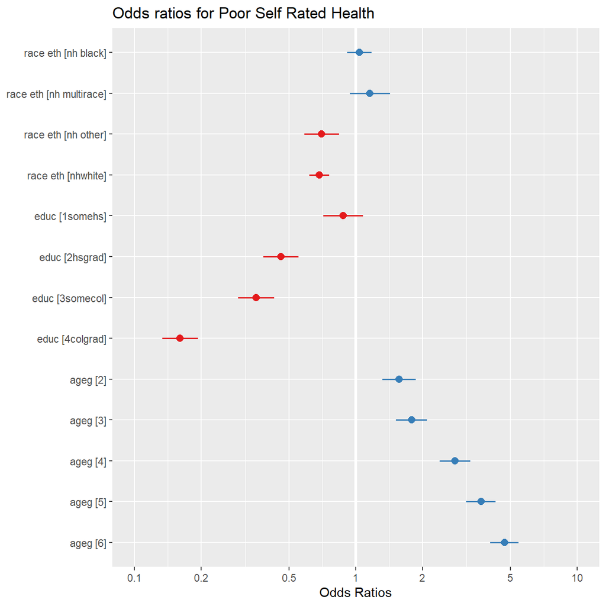

```r
library(sjPlot)
plot_model(fit.logit,
           axis.lim = c(.1, 10), #you may need to modify these
           title = "Odds ratios for Poor Self Rated Health")
```

### Probit model

To get the probit model, you use `link = "probit"` in `svyglm`

```r
#probit model
fit.probit<-svyglm(badhealth~race_eth+educ+ageg,
                   design=des,
                   family=binomial(link= "probit"))
```

# Present both model coefficients next to one another

```r
require(rlang)
t1<-fit.logit%>%
  tbl_regression()

t2<- fit.probit%>%
  tbl_regression()

t_all <- tbl_merge(tbls = list(t1, t2))
t_all
```

| **Characteristic** | **Table 1** **log(OR)**<sup>1</sup> | **Table 1** **95% CI**<sup>1</sup> | **Table 1** **p-value** | **Table 2** **Beta** | **Table 2** **95% CI**<sup>1</sup> | **Table 2** **p-value** |
| --- | --- | --- | --- | --- | --- | --- |
| race_eth |  |  |  |  |  |  |
| hispanic | — | — |  | — | — |  |
| nh_black | 0.04 | -0.09, 0.16 | 0.6 | 0.03 | -0.04, 0.09 | 0.5 |
| nh_multirace | 0.15 | -0.06, 0.35 | 0.2 | 0.08 | -0.04, 0.19 | 0.2 |
| nh_other | -0.36 | -0.54, -0.17 | <0.001 | -0.19 | -0.29, -0.10 | <0.001 |
| nhwhite | -0.38 | -0.48, -0.28 | <0.001 | -0.20 | -0.26, -0.15 | <0.001 |
| educ |  |  |  |  |  |  |
| 0Prim | — | — |  | — | — |  |
| 1somehs | -0.13 | -0.34, 0.08 | 0.2 | -0.09 | -0.21, 0.03 | 0.2 |
| 2hsgrad | -0.78 | -1.0, -0.60 | <0.001 | -0.47 | -0.58, -0.36 | <0.001 |
| 3somecol | -1.0 | -1.2, -0.85 | <0.001 | -0.61 | -0.72, -0.49 | <0.001 |
| 4colgrad | -1.8 | -2.0, -1.6 | <0.001 | -1.0 | -1.1, -0.90 | <0.001 |
| ageg |  |  |  |  |  |  |
| 1 | — | — |  | — | — |  |
| 2 | 0.45 | 0.28, 0.62 | <0.001 | 0.23 | 0.14, 0.31 | <0.001 |
| 3 | 0.58 | 0.42, 0.74 | <0.001 | 0.29 | 0.21, 0.36 | <0.001 |
| 4 | 1.0 | 0.87, 1.2 | <0.001 | 0.52 | 0.44, 0.60 | <0.001 |
| 5 | 1.3 | 1.2, 1.5 | <0.001 | 0.67 | 0.60, 0.75 | <0.001 |
| 6 | 1.5 | 1.4, 1.7 | <0.001 | 0.81 | 0.74, 0.89 | <0.001 |

<sup>*1*</sup> OR = Odds Ratio, CI = Confidence Interval

Similarly, the education variables shows a negative linear trend, with those with more education having lower chances of reporting poor/fair health compared to those with a primary school education (Reference group), and likewise, as people get older, they are more likely to report poor/fair health, compared to those under age 24 (Reference group).

## Fitted Values

As I often say, I like to talk about “interesting cases”. In order to do this, you need the fitted mean for a particular case. This is done by getting the fitted values for that case from the model. To do this, I generate a bunch of “fake people” that have variability in the model covariates, and fit the model for each type of person. This is perhaps overkill in this example because I fit every type of person, ideally you would want a few interesting cases to discuss.

In order to derive these, we effectively “solve the equation” for the model, or another way of saying it, we estimate the conditional mean of y, by specifying the x values that are meaningful for a particular comparison. For example the probability of a white, young college educated person reporting poor health is just the estimate of the model, evaluated at those particular characteristics:

$$\text{Pr(poor/fair health)}
= \frac{1}{1+exp({\beta_0 + \beta_1*white +
\beta_2*young+\beta_3*college})}$$

```r
#get a series of predicted probabilites for different "types" of people for each model
#ref_grid will generate all possible combinations of predictors from a model

library(emmeans)
rg<-ref_grid(fit.logit)

marg_logit<-emmeans(object = rg,
              specs = c( "race_eth",  "educ", "ageg"),
              type="response" )

knitr::kable(marg_logit,  digits = 4)
```

| race_eth | educ | ageg | prob | SE | df | asymp.LCL | asymp.UCL |
| --- | --- | --- | --- | --- | --- | --- | --- |
| hispanic | 0Prim | 1 | 0.1667 | 0.0155 | Inf | 0.1385 | 0.1993 |
| nh_black | 0Prim | 1 | 0.1720 | 0.0173 | Inf | 0.1406 | 0.2086 |
| nh_multirace | 0Prim | 1 | 0.1879 | 0.0227 | Inf | 0.1473 | 0.2365 |
| nh_other | 0Prim | 1 | 0.1230 | 0.0146 | Inf | 0.0971 | 0.1545 |
| nhwhite | 0Prim | 1 | 0.1203 | 0.0124 | Inf | 0.0981 | 0.1468 |
| hispanic | 1somehs | 1 | 0.1492 | 0.0117 | Inf | 0.1278 | 0.1735 |
| nh_black | 1somehs | 1 | 0.1541 | 0.0123 | Inf | 0.1314 | 0.1798 |
| nh_multirace | 1somehs | 1 | 0.1686 | 0.0178 | Inf | 0.1366 | 0.2064 |
| nh_other | 1somehs | 1 | 0.1095 | 0.0113 | Inf | 0.0892 | 0.1337 |
| nhwhite | 1somehs | 1 | 0.1071 | 0.0086 | Inf | 0.0914 | 0.1252 |
| hispanic | 2hsgrad | 1 | 0.0840 | 0.0062 | Inf | 0.0726 | 0.0969 |
| nh_black | 2hsgrad | 1 | 0.0869 | 0.0064 | Inf | 0.0751 | 0.1004 |
| nh_multirace | 2hsgrad | 1 | 0.0959 | 0.0103 | Inf | 0.0775 | 0.1180 |
| nh_other | 2hsgrad | 1 | 0.0604 | 0.0059 | Inf | 0.0498 | 0.0731 |
| nhwhite | 2hsgrad | 1 | 0.0590 | 0.0041 | Inf | 0.0514 | 0.0676 |
| hispanic | 3somecol | 1 | 0.0662 | 0.0051 | Inf | 0.0568 | 0.0769 |
| nh_black | 3somecol | 1 | 0.0685 | 0.0052 | Inf | 0.0591 | 0.0793 |
| nh_multirace | 3somecol | 1 | 0.0757 | 0.0083 | Inf | 0.0610 | 0.0937 |
| nh_other | 3somecol | 1 | 0.0473 | 0.0047 | Inf | 0.0389 | 0.0575 |
| nhwhite | 3somecol | 1 | 0.0462 | 0.0033 | Inf | 0.0402 | 0.0531 |
| hispanic | 4colgrad | 1 | 0.0311 | 0.0026 | Inf | 0.0265 | 0.0365 |
| nh_black | 4colgrad | 1 | 0.0323 | 0.0027 | Inf | 0.0274 | 0.0379 |
| nh_multirace | 4colgrad | 1 | 0.0358 | 0.0042 | Inf | 0.0285 | 0.0450 |
| nh_other | 4colgrad | 1 | 0.0220 | 0.0022 | Inf | 0.0181 | 0.0268 |
| nhwhite | 4colgrad | 1 | 0.0215 | 0.0016 | Inf | 0.0185 | 0.0250 |
| hispanic | 0Prim | 2 | 0.2389 | 0.0184 | Inf | 0.2047 | 0.2768 |
| nh_black | 0Prim | 2 | 0.2458 | 0.0209 | Inf | 0.2072 | 0.2889 |
| nh_multirace | 0Prim | 2 | 0.2663 | 0.0270 | Inf | 0.2168 | 0.3224 |
| nh_other | 0Prim | 2 | 0.1803 | 0.0188 | Inf | 0.1464 | 0.2201 |
| nhwhite | 0Prim | 2 | 0.1767 | 0.0153 | Inf | 0.1487 | 0.2086 |

[output cut: 120 more lines]

You can compare these to the probit model estimates, they are very similar

```r
rg<-ref_grid(fit.probit)

marg_probit<-emmeans(object = rg,
              specs = c( "race_eth", "ageg"),
              type="response" )
knitr::kable(marg_probit, digits = 4)
```

| race_eth | ageg | prob | SE | df | asymp.LCL | asymp.UCL |
| --- | --- | --- | --- | --- | --- | --- |
| hispanic | 1 | 0.0929 | 0.0064 | Inf | 0.0809 | 0.1062 |
| nh_black | 1 | 0.0971 | 0.0070 | Inf | 0.0840 | 0.1116 |
| nh_multirace | 1 | 0.1064 | 0.0116 | Inf | 0.0855 | 0.1308 |
| nh_other | 1 | 0.0648 | 0.0065 | Inf | 0.0529 | 0.0786 |
| nhwhite | 1 | 0.0633 | 0.0046 | Inf | 0.0548 | 0.0727 |
| hispanic | 2 | 0.1361 | 0.0076 | Inf | 0.1218 | 0.1515 |
| nh_black | 2 | 0.1416 | 0.0083 | Inf | 0.1260 | 0.1585 |
| nh_multirace | 2 | 0.1537 | 0.0138 | Inf | 0.1282 | 0.1823 |
| nh_other | 2 | 0.0984 | 0.0083 | Inf | 0.0830 | 0.1157 |
| nhwhite | 2 | 0.0964 | 0.0051 | Inf | 0.0868 | 0.1066 |
| hispanic | 3 | 0.1497 | 0.0074 | Inf | 0.1357 | 0.1647 |
| nh_black | 3 | 0.1556 | 0.0081 | Inf | 0.1403 | 0.1720 |
| nh_multirace | 3 | 0.1685 | 0.0145 | Inf | 0.1416 | 0.1984 |
| nh_other | 3 | 0.1093 | 0.0085 | Inf | 0.0935 | 0.1269 |
| nhwhite | 3 | 0.1071 | 0.0049 | Inf | 0.0978 | 0.1170 |
| hispanic | 4 | 0.2105 | 0.0098 | Inf | 0.1919 | 0.2302 |
| nh_black | 4 | 0.2178 | 0.0096 | Inf | 0.1996 | 0.2370 |
| nh_multirace | 4 | 0.2336 | 0.0177 | Inf | 0.2003 | 0.2697 |
| nh_other | 4 | 0.1593 | 0.0110 | Inf | 0.1386 | 0.1819 |
| nhwhite | 4 | 0.1565 | 0.0061 | Inf | 0.1448 | 0.1688 |
| hispanic | 5 | 0.2570 | 0.0103 | Inf | 0.2372 | 0.2776 |
| nh_black | 5 | 0.2651 | 0.0100 | Inf | 0.2459 | 0.2851 |
| nh_multirace | 5 | 0.2826 | 0.0192 | Inf | 0.2461 | 0.3214 |
| nh_other | 5 | 0.1989 | 0.0126 | Inf | 0.1752 | 0.2245 |
| nhwhite | 5 | 0.1957 | 0.0063 | Inf | 0.1836 | 0.2082 |
| hispanic | 6 | 0.3049 | 0.0108 | Inf | 0.2841 | 0.3263 |
| nh_black | 6 | 0.3137 | 0.0103 | Inf | 0.2938 | 0.3342 |
| nh_multirace | 6 | 0.3325 | 0.0204 | Inf | 0.2936 | 0.3734 |
| nh_other | 6 | 0.2410 | 0.0136 | Inf | 0.2151 | 0.2685 |
| nhwhite | 6 | 0.2373 | 0.0060 | Inf | 0.2258 | 0.2492 |

Which show us the estimated probability of reporting poor/fair health for each specified type of “typical person” that we generate. For example, let’s look at the probability for a Non-Hispanic white with a college education, compared to a Hispanic person, age 39-59 with a college education:

```r
comps<-as.data.frame(marg_logit)

comps[comps$race_eth=="hispanic" & comps$educ == "4colgrad" , ]
```

|  | race_eth | educ | ageg | prob | SE | df | asymp.LCL | asymp.UCL |
| --- | --- | --- | --- | --- | --- | --- | --- | --- |
| 21 | hispanic | 4colgrad | 1 | 0.03112396 | 0.002557349 | Inf | 0.02648394 | 0.03654639 |
| 46 | hispanic | 4colgrad | 2 | 0.04798035 | 0.003283778 | Inf | 0.04193902 | 0.05484211 |
| 71 | hispanic | 4colgrad | 3 | 0.05427261 | 0.003502586 | Inf | 0.04780300 | 0.06156120 |
| 96 | hispanic | 4colgrad | 4 | 0.08268753 | 0.005103157 | Inf | 0.07322022 | 0.09325579 |
| 121 | hispanic | 4colgrad | 5 | 0.10567168 | 0.006113943 | Inf | 0.09427374 | 0.11826772 |
| 146 | hispanic | 4colgrad | 6 | 0.13105565 | 0.007294514 | Inf | 0.11740870 | 0.14602640 |

```r
comps[comps$race_eth=="nhwhite" & comps$educ == "4colgrad" , ]
```

|  | race_eth | educ | ageg | prob | SE | df | asymp.LCL | asymp.UCL |
| --- | --- | --- | --- | --- | --- | --- | --- | --- |
| 25 | nhwhite | 4colgrad | 1 | 0.02149733 | 0.001641181 | Inf | 0.01850543 | 0.02496066 |
| 50 | nhwhite | 4colgrad | 2 | 0.03331935 | 0.001913593 | Inf | 0.02976589 | 0.03728072 |
| 75 | nhwhite | 4colgrad | 3 | 0.03776520 | 0.002016753 | Inf | 0.03400520 | 0.04192292 |
| 100 | nhwhite | 4colgrad | 4 | 0.05806818 | 0.002644952 | Inf | 0.05309615 | 0.06347460 |
| 125 | nhwhite | 4colgrad | 5 | 0.07476681 | 0.002986798 | Inf | 0.06911939 | 0.08083559 |
| 150 | nhwhite | 4colgrad | 6 | 0.09350312 | 0.003319328 | Inf | 0.08719720 | 0.10021501 |